# regrids_example

In this example we work through the following steps:

1. Import the cf package.
2. Read a field from disk and find a summary of its contents.
3. Take a latitute-longitude slice of the field.
4. Import the cfplot package.
5. Create a blockfill plot of the latitude-longitude slice.
6. Read in a second field and find a summary of its contents.
7. Check the cyclicity of the fields are set correctly.
8. Regrid the first field to the grid of the second conservatively and find a summary of the resulting field's contents.
9. Plot a latitute-longitude slice of the field.

**1.** Import the cf package.

```python
import cf
```

**2.** Read a field from disk and find a summary of its contents.

```python
f = cf.read('cru_ts3.22.2001.2010.pre.dat.nc')
f
```

```
<CF Field: long_name:precipitation(long_name:time(120), long_name:latitude(360), long_name:longitude(720)) mm>
```

```python
print f
```

```
long_name:precipitation field summary
-------------------------------------
Data           : long_name:precipitation(long_name:time(120), long_name:latitude(360), long_name:longitude(720)) mm
Axes           : long_name:time(120) = [2001-01-16 00:00:00, ..., 2010-12-16 00:00:00] gregorian
               : long_name:latitude(360) = [-89.75, ..., 89.75] degrees_north
               : long_name:longitude(720) = [-179.75, ..., 179.75] degrees_east
```

**3.** Take a latitute-longitude slice of the field.

```python
g = f.subspace[0]
g
```

```
<CF Field: long_name:precipitation(long_name:time(1), long_name:latitude(360), long_name:longitude(720)) mm>
```

**4.** Import the cfplot package.

```python
%matplotlib inline

import cfplot as cfp
```

**5.** Create a blockfill plot of the latitude-longitude slice.

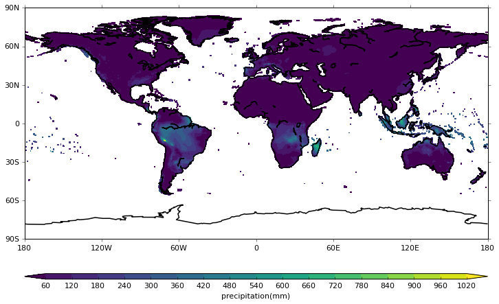

```python
cfp.con(g, blockfill=True)
```

**6.** Read in a second field and find a summary of its contents.

```python
g = cf.read('N96_DJF_precip_means.nc')
g
```

```
<CF Field: long_name:TOTAL PRECIPITATION RATE     KG/M2/S(long_name:t(1), long_name:Surface(1), latitude(145), longitude(192)) mm/day>
```

```python
print g
```

```
long_name:TOTAL PRECIPITATION RATE     KG/M2/S field summary
------------------------------------------------------------
Data           : long_name:TOTAL PRECIPITATION RATE     KG/M2/S(long_name:t(1), long_name:Surface(1), latitude(145), longitude(192)) mm/day
Cell methods   : long_name:t: mean
Axes           : long_name:t(1) = [1996-07-16 00:00:00] 360_day
               : long_name:Surface(1) = [0.0]
               : latitude(145) = [-90.0, ..., 90.0] degrees_north
               : longitude(192) = [0.0, ..., 358.125] degrees_east
```

**7.** Check the cyclicity of the fields are set correctly.

```python
f.iscyclic('X')
```

```
False
```

```python
f.cyclic('X', period=cf.Data(360, 'degrees'))
f.iscyclic('X')
```

```
True
```

```python
g.iscyclic('X')
```

```
False
```

```python
g.cyclic('X', period=cf.Data(360, 'degrees'))
g.iscyclic('X')
```

```
True
```

**8.** Regrid the first field to the grid of the second conservatively and find a summary of the resulting field's contents.

```python
h = f.regrids(g)
h
```

```
<CF Field: long_name:precipitation(long_name:time(120), latitude(145), longitude(192)) mm>
```

```python
print h
```

```
long_name:precipitation field summary
-------------------------------------
Data           : long_name:precipitation(long_name:time(120), latitude(145), longitude(192)) mm
Axes           : long_name:time(120) = [2001-01-16 00:00:00, ..., 2010-12-16 00:00:00] gregorian
               : latitude(145) = [-90.0, ..., 90.0] degrees_north
               : longitude(192) = [0.0, ..., 358.125] degrees_east
```

**9.** Plot a latitute-longitude slice of the field.

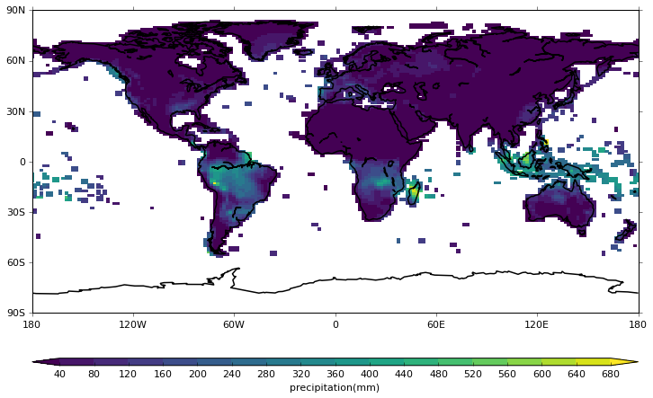

```python
cfp.con(h.subspace[0], blockfill=True)
```